# SSDI_Project

```python
import numpy as np
import pandas as pd
import matplotlib.pyplot as plt
import seaborn as sns

# Stats
from scipy import stats
from scipy.stats import t, norm, binom
from scipy.optimize import minimize

# StatsModels
import statsmodels.api as sm
import statsmodels.formula.api as smf
from statsmodels.formula.api import ols
from statsmodels.multivariate.manova import MANOVA
from statsmodels.stats.multicomp import pairwise_tukeyhsd
from statsmodels.stats.outliers_influence import variance_inflation_factor

# Scikit-learn
from sklearn.linear_model import Ridge, RidgeCV, Lasso, LassoCV, LinearRegression
from sklearn.model_selection import train_test_split, KFold, cross_val_score
from sklearn.preprocessing import StandardScaler, OneHotEncoder, minmax_scale , LabelEncoder
```

Read the File - Employee Data SSDI

```python
df1 = pd.read_csv("C:/Users/Akshat Mistry/Downloads/Employee_Data_SSDI.csv")
```

```python
df1.head()
```

|  |  | Attrition | BusinessTravel | DailyRate | Department | DistanceFromHome | Education | EducationField | EmployeeCount | EmployeeNumber | ... | RelationshipSatisfaction | StandardHours | StockOptionLevel | TotalWorkingYears | TrainingTimesLastYear | WorkLifeBalance | YearsAtCompany | YearsInCurrentRole | YearsSinceLastPromotion | YearsWithCurrManager |
| --- | --- | --- | --- | --- | --- | --- | --- | --- | --- | --- | --- | --- | --- | --- | --- | --- | --- | --- | --- | --- | --- |
| 0 | 41 | Yes | Travel_Rarely | 1102 | Sales | 1 | 2 | Life Sciences | 1 | 1 | ... | 1 | 80 | 0 | 8 | 0 | 1 | 6 | 4 | 0 | 5 |
| 1 | 49 | No | Travel_Frequently | 279 | Research & Development | 8 | 1 | Life Sciences | 1 | 2 | ... | 4 | 80 | 1 | 10 | 3 | 3 | 10 | 7 | 1 | 7 |
| 2 | 37 | Yes | Travel_Rarely | 1373 | Research & Development | 2 | 2 | Other | 1 | 4 | ... | 2 | 80 | 0 | 7 | 3 | 3 | 0 | 0 | 0 | 0 |
| 3 | 33 | No | Travel_Frequently | 1392 | Research & Development | 3 | 4 | Life Sciences | 1 | 5 | ... | 3 | 80 | 0 | 8 | 3 | 3 | 8 | 7 | 3 | 0 |
| 4 | 27 | No | Travel_Rarely | 591 | Research & Development | 2 | 1 | Medical | 1 | 7 | ... | 4 | 80 | 1 | 6 | 3 | 3 | 2 | 2 | 2 | 2 |

5 rows × 35 columns

Step1 --> Check for any Missing values

```python
df1.isnull().sum()
```

```
                            0
Attrition                   0
BusinessTravel              0
DailyRate                   0
Department                  0
DistanceFromHome            0
Education                   0
EducationField              0
EmployeeCount               0
EmployeeNumber              0
EnvironmentSatisfaction     0
Gender                      0
HourlyRate                  0
JobInvolvement              0
JobLevel                    0
JobRole                     0
JobSatisfaction             0
MaritalStatus               0
MonthlyIncome               0
MonthlyRate                 0
NumCompaniesWorked          0
Over18                      0
OverTime                    0
PercentSalaryHike           0
PerformanceRating           0
RelationshipSatisfaction    0
StandardHours               0
StockOptionLevel            0
TotalWorkingYears           0
TrainingTimesLastYear       0
WorkLifeBalance             0
YearsAtCompany              0
YearsInCurrentRole          0
YearsSinceLastPromotion     0
YearsWithCurrManager        0
dtype: int64
```

Result: THERE ARE NO MISSING LIBRARIES IN THE DATASET "Employee_Data_SSDI"

Step2 ---> Sort the Variables and check which ones are continuous and which ones are factor variables .

```python
df1["JobRole"].unique()
```

```
array(['Sales Executive', 'Research Scientist', 'Laboratory Technician',
       'Manufacturing Director', 'Healthcare Representative', 'Manager',
       'Sales Representative', 'Research Director', 'Human Resources'],
      dtype=object)
```

Factor Variables : 1Attrition --> Yes / No 2BusinessTravel --> Travel_Rarely , Travel_Frequently , Non-Travel 3Department --> Sales , Research & Development , Human Resources Education --> 1,2,3,4,5 4EducationField --> Life Sciences , Other , Medical , Marketing , Technical Degree , Human Resources EmployeeCount --> 1 EnvironmentSatisfaction --> 1,2,3,4 5Gender --> Male , Female JobInvolvement --> 1,2,3,4 JobLevel --> 1,2,3,4 6JobRole --> Sales Executive , Research Scientist , Laboratory Technician , Manufacturing Director , Healthcare Representative , Manager , Sales Representative , Research Director , Human Resources JobSatisfaction --> 1,2,3,4 7MaritalStatus --> Single, Married , Divorced NumCompaniesWorked --> 0,1,2,3,4,5,6,7,8,9 Over18 --> Y 8OverTime --> Yes , No PerformanceRating --> 3,4 RelationshipSatisfaction --> 1,2,3,4 StandardHours --> 80 StockOptionLevel --> 0,1,2,3 TrainingTimesLastYear --> 0,1,2,3,4,5,6 WorkLifeBalance --> 1,2,3,4

Continuous: DailyRate DistanceFromHome HourlyRate MonthlyIncome MonthlyRate PercentSalaryHike TotalWorkingYears YearsAtCompany YearsInCurrentRole YearsSinceLastPromotion YearsWithCurrManager

Identifier: EmployeeNumber , SO IT SHOULD NOT BE USED

Step 3 --> Now , we will do label encoding to assign numerical values

```python
from sklearn.preprocessing import LabelEncoder

# Create a copy of the dataframe to avoid modifying original
df3 = df1.copy()

# List of factor variables from your list
factor_vars = ['Attrition', 'BusinessTravel', 'Department', 'EducationField','Gender', 'JobRole', 'MaritalStatus','OverTime']

# Apply Label Encoding to each
le = LabelEncoder()
for col in factor_vars:
    df3[col] = le.fit_transform(df3[col])

# View the encoded DataFrame
df3.head()
```

|  |  | Attrition | BusinessTravel | DailyRate | Department | DistanceFromHome | Education | EducationField | EmployeeCount | EmployeeNumber | ... | RelationshipSatisfaction | StandardHours | StockOptionLevel | TotalWorkingYears | TrainingTimesLastYear | WorkLifeBalance | YearsAtCompany | YearsInCurrentRole | YearsSinceLastPromotion | YearsWithCurrManager |
| --- | --- | --- | --- | --- | --- | --- | --- | --- | --- | --- | --- | --- | --- | --- | --- | --- | --- | --- | --- | --- | --- |
| 0 | 41 | 1 | 2 | 1102 | 2 | 1 | 2 | 1 | 1 | 1 | ... | 1 | 80 | 0 | 8 | 0 | 1 | 6 | 4 | 0 | 5 |
| 1 | 49 | 0 | 1 | 279 | 1 | 8 | 1 | 1 | 1 | 2 | ... | 4 | 80 | 1 | 10 | 3 | 3 | 10 | 7 | 1 | 7 |
| 2 | 37 | 1 | 2 | 1373 | 1 | 2 | 2 | 4 | 1 | 4 | ... | 2 | 80 | 0 | 7 | 3 | 3 | 0 | 0 | 0 | 0 |
| 3 | 33 | 0 | 1 | 1392 | 1 | 3 | 4 | 1 | 1 | 5 | ... | 3 | 80 | 0 | 8 | 3 | 3 | 8 | 7 | 3 | 0 |
| 4 | 27 | 0 | 2 | 591 | 1 | 2 | 1 | 3 | 1 | 7 | ... | 4 | 80 | 1 | 6 | 3 | 3 | 2 | 2 | 2 | 2 |

5 rows × 35 columns

Monthly Income Analysis - ANOVA

```python
aa = smf.ols("MonthlyIncome ~ Attrition + BusinessTravel + Department  + Education+ EducationField + EnvironmentSatisfaction + Gender + JobRole + JobLevel +JobInvolvement +JobSatisfaction + MaritalStatus + NumCompaniesWorked + OverTime + PerformanceRating + RelationshipSatisfaction + StockOptionLevel + TrainingTimesLastYear + WorkLifeBalance" , data = df3).fit()
aa.summary()
```

OLS Regression Results

| Dep. Variable: | MonthlyIncome | R-squared: | 0.906 |
| --- | --- | --- | --- |
| Model: | OLS | Adj. R-squared: | 0.905 |
| Method: | Least Squares | F-statistic: | 737.9 |
| Date: | Wed, 09 Apr 2025 | Prob (F-statistic): | 0.00 |
| Time: | 07:43:42 | Log-Likelihood: | -12777. |
| No. Observations: | 1470 | AIC: | 2.559e+04 |
| Df Residuals: | 1450 | BIC: | 2.570e+04 |
| Df Model: | 19 |  |  |
| Covariance Type: | nonrobust |  |  |

|  | coef | std err | t | P>\|t\| | [0.025 | 0.975] |
| --- | --- | --- | --- | --- | --- | --- |
| Intercept | -1399.4709 | 505.707 | -2.767 | 0.006 | -2391.466 | -407.476 |
| Attrition | -9.6045 | 113.728 | -0.084 | 0.933 | -232.693 | 213.484 |
| BusinessTravel | 107.9618 | 57.137 | 1.890 | 0.059 | -4.118 | 220.042 |
| Department | -573.5265 | 98.606 | -5.816 | 0.000 | -766.953 | -380.100 |
| Education | -13.2431 | 37.531 | -0.353 | 0.724 | -86.864 | 60.378 |
| EducationField | 8.4648 | 28.600 | 0.296 | 0.767 | -47.637 | 64.566 |
| EnvironmentSatisfaction | -38.2509 | 35.125 | -1.089 | 0.276 | -107.152 | 30.651 |
| Gender | 53.0698 | 77.941 | 0.681 | 0.496 | -99.819 | 205.959 |
| JobRole | 60.7463 | 21.051 | 2.886 | 0.004 | 19.453 | 102.039 |
| JobLevel | 4072.0911 | 36.504 | 111.553 | 0.000 | 4000.486 | 4143.696 |
| JobInvolvement | -40.6460 | 53.981 | -0.753 | 0.452 | -146.536 | 65.244 |
| JobSatisfaction | -14.7543 | 34.781 | -0.424 | 0.671 | -82.981 | 53.472 |
| MaritalStatus | -62.7369 | 70.341 | -0.892 | 0.373 | -200.717 | 75.243 |
| NumCompaniesWorked | 24.1938 | 15.595 | 1.551 | 0.121 | -6.398 | 54.786 |
| OverTime | 54.9517 | 88.308 | 0.622 | 0.534 | -118.273 | 228.176 |
| PerformanceRating | 35.8979 | 105.220 | 0.341 | 0.733 | -170.502 | 242.298 |
| RelationshipSatisfaction | 16.3593 | 35.328 | 0.463 | 0.643 | -52.940 | 85.659 |
| StockOptionLevel | -79.6904 | 59.679 | -1.335 | 0.182 | -196.756 | 37.375 |
| TrainingTimesLastYear | -3.1061 | 29.691 | -0.105 | 0.917 | -61.348 | 55.136 |
| WorkLifeBalance | -27.7082 | 53.894 | -0.514 | 0.607 | -133.427 | 78.011 |

| Omnibus: | 8.220 | Durbin-Watson: | 2.065 |
| --- | --- | --- | --- |
| Prob(Omnibus): | 0.016 | Jarque-Bera (JB): | 10.939 |
| Skew: | 0.006 | Prob(JB): | 0.00421 |
| Kurtosis: | 3.422 | Cond. No. | 142. |

Notes:  
[1] Standard Errors assume that the covariance matrix of the errors is correctly specified.

```python
from statsmodels.stats.multicomp import pairwise_tukeyhsd
import pandas as pd

# Step 1: Run Tukey
tukey = pairwise_tukeyhsd(
    df3["MonthlyIncome"],
    groups=df3["Department"].astype(str) + df3["JobRole"].astype(str) + df3["JobLevel"].astype(str)
)

# Step 2: Convert to raw data (list of lists)
tukey_data = tukey.summary().data

# Step 3: Save to CSV
tukey_df = pd.DataFrame(tukey_data[1:], columns=tukey_data[0])  # first row as header
tukey_df.to_csv("tukey_results.csv", index=False)
```

```python
# Load it again
tukey_csv = pd.read_csv("tukey_results.csv")
```

135 281 **-16727.2763** 0 -17680.7381 -15773.8145 TRUE

Here , the highest difference between the monthly income is when : Group1 --> 135 and 281

```python
from scipy.stats import ttest_ind
```

```python
df3["Group"] = df3["Department"].astype(str) + df3["JobRole"].astype(str) + df3["JobLevel"].astype(str)
group_135 = df3[df3["Group"] == "135"]["MonthlyIncome"]
group_281 = df3[df3["Group"] == "281"]["MonthlyIncome"]
t_stat, p_value = ttest_ind(group_135, group_281, equal_var=False)  # Welch's t-test
print("T-Statistic:", t_stat)
print("P-Value:", p_value)
```

```
T-Statistic: 133.45697403689366
P-Value: 9.628874685109034e-62
```

There is a statistically significant difference in the mean MonthlyIncome between Group 135 and Group 281. Group 135 has a significantly higher Monthly Income compared to Group 281, based on the t-test results.

PercentSalaryHike - ANOVA

```python
aa = smf.ols("PercentSalaryHike ~ Attrition + BusinessTravel + Department  + Education+ EducationField + EnvironmentSatisfaction + Gender + JobRole + JobLevel +JobInvolvement +JobSatisfaction + MaritalStatus + NumCompaniesWorked + OverTime + PerformanceRating + RelationshipSatisfaction + StockOptionLevel + TrainingTimesLastYear + WorkLifeBalance" , data = df3).fit()
aa.summary()
```

OLS Regression Results

| Dep. Variable: | PercentSalaryHike | R-squared: | 0.601 |
| --- | --- | --- | --- |
| Model: | OLS | Adj. R-squared: | 0.596 |
| Method: | Least Squares | F-statistic: | 114.8 |
| Date: | Wed, 09 Apr 2025 | Prob (F-statistic): | 1.97e-272 |
| Time: | 07:43:59 | Log-Likelihood: | -3317.8 |
| No. Observations: | 1470 | AIC: | 6676. |
| Df Residuals: | 1450 | BIC: | 6781. |
| Df Model: | 19 |  |  |
| Covariance Type: | nonrobust |  |  |

|  | coef | std err | t | P>\|t\| | [0.025 | 0.975] |
| --- | --- | --- | --- | --- | --- | --- |
| Intercept | -9.5863 | 0.811 | -11.815 | 0.000 | -11.178 | -7.995 |
| Attrition | -0.2160 | 0.182 | -1.184 | 0.237 | -0.574 | 0.142 |
| BusinessTravel | -0.0480 | 0.092 | -0.524 | 0.600 | -0.228 | 0.132 |
| Department | 0.0298 | 0.158 | 0.188 | 0.851 | -0.281 | 0.340 |
| Education | 0.0275 | 0.060 | 0.456 | 0.648 | -0.091 | 0.146 |
| EducationField | -0.0170 | 0.046 | -0.370 | 0.712 | -0.107 | 0.073 |
| EnvironmentSatisfaction | -0.0325 | 0.056 | -0.576 | 0.564 | -0.143 | 0.078 |
| Gender | 0.1116 | 0.125 | 0.892 | 0.372 | -0.134 | 0.357 |
| JobRole | 0.0211 | 0.034 | 0.625 | 0.532 | -0.045 | 0.087 |
| JobLevel | -0.0678 | 0.059 | -1.158 | 0.247 | -0.183 | 0.047 |
| JobInvolvement | 0.0159 | 0.087 | 0.184 | 0.854 | -0.154 | 0.186 |
| JobSatisfaction | 0.0472 | 0.056 | 0.846 | 0.398 | -0.062 | 0.157 |
| MaritalStatus | 0.0982 | 0.113 | 0.870 | 0.385 | -0.123 | 0.320 |
| NumCompaniesWorked | 0.0112 | 0.025 | 0.446 | 0.656 | -0.038 | 0.060 |
| OverTime | -0.0090 | 0.142 | -0.063 | 0.949 | -0.287 | 0.269 |
| PerformanceRating | 7.8415 | 0.169 | 46.449 | 0.000 | 7.510 | 8.173 |
| RelationshipSatisfaction | -0.0574 | 0.057 | -1.013 | 0.311 | -0.169 | 0.054 |
| StockOptionLevel | 0.0584 | 0.096 | 0.610 | 0.542 | -0.129 | 0.246 |
| TrainingTimesLastYear | 0.0181 | 0.048 | 0.381 | 0.703 | -0.075 | 0.112 |
| WorkLifeBalance | -0.0302 | 0.086 | -0.350 | 0.727 | -0.200 | 0.139 |

| Omnibus: | 125.249 | Durbin-Watson: | 2.111 |
| --- | --- | --- | --- |
| Prob(Omnibus): | 0.000 | Jarque-Bera (JB): | 111.733 |
| Skew: | 0.603 | Prob(JB): | 5.46e-25 |
| Kurtosis: | 2.393 | Cond. No. | 142. |

Notes:  
[1] Standard Errors assume that the covariance matrix of the errors is correctly specified.

With 95% confidence, PerformanceRating is the only significant predictor of PercentSalaryHike.

Years At Company - ANOVA

```python
aa = smf.ols("YearsAtCompany ~ Attrition + BusinessTravel + Department  + Education+ EducationField + EnvironmentSatisfaction + Gender + JobRole + JobLevel +JobInvolvement +JobSatisfaction + MaritalStatus + NumCompaniesWorked + OverTime + PerformanceRating + RelationshipSatisfaction + StockOptionLevel + TrainingTimesLastYear + WorkLifeBalance" , data = df3).fit()
aa.summary()
```

OLS Regression Results

| Dep. Variable: | YearsAtCompany | R-squared: | 0.331 |
| --- | --- | --- | --- |
| Model: | OLS | Adj. R-squared: | 0.323 |
| Method: | Least Squares | F-statistic: | 37.84 |
| Date: | Wed, 09 Apr 2025 | Prob (F-statistic): | 2.60e-112 |
| Time: | 07:43:59 | Log-Likelihood: | -4454.0 |
| No. Observations: | 1470 | AIC: | 8948. |
| Df Residuals: | 1450 | BIC: | 9054. |
| Df Model: | 19 |  |  |
| Covariance Type: | nonrobust |  |  |

|  | coef | std err | t | P>\|t\| | [0.025 | 0.975] |
| --- | --- | --- | --- | --- | --- | --- |
| Intercept | 2.6685 | 1.758 | 1.518 | 0.129 | -0.779 | 6.116 |
| Attrition | -0.4225 | 0.395 | -1.069 | 0.285 | -1.198 | 0.353 |
| BusinessTravel | -0.1864 | 0.199 | -0.939 | 0.348 | -0.576 | 0.203 |
| Department | -0.1901 | 0.343 | -0.555 | 0.579 | -0.862 | 0.482 |
| Education | 0.2369 | 0.130 | 1.816 | 0.070 | -0.019 | 0.493 |
| EducationField | 0.0375 | 0.099 | 0.377 | 0.706 | -0.157 | 0.232 |
| EnvironmentSatisfaction | 0.0090 | 0.122 | 0.074 | 0.941 | -0.230 | 0.248 |
| Gender | -0.2273 | 0.271 | -0.839 | 0.402 | -0.759 | 0.304 |
| JobRole | -0.0827 | 0.073 | -1.130 | 0.259 | -0.226 | 0.061 |
| JobLevel | 3.0614 | 0.127 | 24.132 | 0.000 | 2.813 | 3.310 |
| JobInvolvement | -0.1451 | 0.188 | -0.774 | 0.439 | -0.513 | 0.223 |
| JobSatisfaction | -0.0825 | 0.121 | -0.682 | 0.495 | -0.320 | 0.155 |
| MaritalStatus | -0.1854 | 0.244 | -0.758 | 0.448 | -0.665 | 0.294 |
| NumCompaniesWorked | -0.5057 | 0.054 | -9.331 | 0.000 | -0.612 | -0.399 |
| OverTime | -0.1323 | 0.307 | -0.431 | 0.666 | -0.734 | 0.470 |
| PerformanceRating | 0.1988 | 0.366 | 0.544 | 0.587 | -0.518 | 0.916 |
| RelationshipSatisfaction | 0.1014 | 0.123 | 0.826 | 0.409 | -0.139 | 0.342 |
| StockOptionLevel | -0.0343 | 0.207 | -0.166 | 0.868 | -0.441 | 0.373 |
| TrainingTimesLastYear | -0.0045 | 0.103 | -0.044 | 0.965 | -0.207 | 0.198 |
| WorkLifeBalance | -0.1099 | 0.187 | -0.587 | 0.557 | -0.477 | 0.257 |

| Omnibus: | 210.790 | Durbin-Watson: | 2.032 |
| --- | --- | --- | --- |
| Prob(Omnibus): | 0.000 | Jarque-Bera (JB): | 523.260 |
| Skew: | 0.789 | Prob(JB): | 2.37e-114 |
| Kurtosis: | 5.461 | Cond. No. | 142. |

Notes:  
[1] Standard Errors assume that the covariance matrix of the errors is correctly specified.

With 95% confidence, only JobLevel and NumCompaniesWorked are significant predictors of how many years an employee stays at a company.

Years Since Last Promotion - OLS

```python
aa = smf.ols("YearsSinceLastPromotion ~ Attrition + BusinessTravel + Department  + Education+ EducationField + EnvironmentSatisfaction + Gender + JobRole + JobLevel +JobInvolvement +JobSatisfaction + MaritalStatus + NumCompaniesWorked + OverTime + PerformanceRating + RelationshipSatisfaction + StockOptionLevel + TrainingTimesLastYear + WorkLifeBalance" , data = df3).fit()
aa.summary()
```

OLS Regression Results

| Dep. Variable: | YearsSinceLastPromotion | R-squared: | 0.141 |
| --- | --- | --- | --- |
| Model: | OLS | Adj. R-squared: | 0.130 |
| Method: | Least Squares | F-statistic: | 12.57 |
| Date: | Wed, 09 Apr 2025 | Prob (F-statistic): | 1.13e-36 |
| Time: | 07:43:59 | Log-Likelihood: | -3693.3 |
| No. Observations: | 1470 | AIC: | 7427. |
| Df Residuals: | 1450 | BIC: | 7533. |
| Df Model: | 19 |  |  |
| Covariance Type: | nonrobust |  |  |

|  | coef | std err | t | P>\|t\| | [0.025 | 0.975] |
| --- | --- | --- | --- | --- | --- | --- |
| Intercept | -0.5120 | 1.048 | -0.489 | 0.625 | -2.567 | 1.543 |
| Attrition | 0.3978 | 0.236 | 1.688 | 0.092 | -0.064 | 0.860 |
| BusinessTravel | -0.1741 | 0.118 | -1.471 | 0.141 | -0.406 | 0.058 |
| Department | 0.1189 | 0.204 | 0.582 | 0.561 | -0.282 | 0.520 |
| Education | 0.1021 | 0.078 | 1.314 | 0.189 | -0.050 | 0.255 |
| EducationField | 0.0448 | 0.059 | 0.756 | 0.450 | -0.071 | 0.161 |
| EnvironmentSatisfaction | 0.0708 | 0.073 | 0.973 | 0.331 | -0.072 | 0.213 |
| Gender | -0.1326 | 0.161 | -0.821 | 0.412 | -0.449 | 0.184 |
| JobRole | -0.0442 | 0.044 | -1.013 | 0.311 | -0.130 | 0.041 |
| JobLevel | 1.0706 | 0.076 | 14.158 | 0.000 | 0.922 | 1.219 |
| JobInvolvement | -0.0559 | 0.112 | -0.500 | 0.617 | -0.275 | 0.163 |
| JobSatisfaction | -0.0499 | 0.072 | -0.692 | 0.489 | -0.191 | 0.091 |
| MaritalStatus | -0.0105 | 0.146 | -0.072 | 0.942 | -0.296 | 0.275 |
| NumCompaniesWorked | -0.1294 | 0.032 | -4.007 | 0.000 | -0.193 | -0.066 |
| OverTime | -0.1975 | 0.183 | -1.079 | 0.281 | -0.556 | 0.161 |
| PerformanceRating | 0.2237 | 0.218 | 1.026 | 0.305 | -0.204 | 0.651 |
| RelationshipSatisfaction | 0.1054 | 0.073 | 1.440 | 0.150 | -0.038 | 0.249 |
| StockOptionLevel | 0.0672 | 0.124 | 0.543 | 0.587 | -0.175 | 0.310 |
| TrainingTimesLastYear | -0.0050 | 0.062 | -0.081 | 0.935 | -0.126 | 0.116 |
| WorkLifeBalance | -0.0305 | 0.112 | -0.273 | 0.785 | -0.249 | 0.189 |

| Omnibus: | 388.634 | Durbin-Watson: | 1.982 |
| --- | --- | --- | --- |
| Prob(Omnibus): | 0.000 | Jarque-Bera (JB): | 864.089 |
| Skew: | 1.479 | Prob(JB): | 2.32e-188 |
| Kurtosis: | 5.316 | Cond. No. | 142. |

Notes:  
[1] Standard Errors assume that the covariance matrix of the errors is correctly specified.

Employees with higher job levels tend to have more time since their last promotion, while those who’ve worked at more companies tend to have less time since their last promotion

Linear Regression

```python
from sklearn.preprocessing import StandardScaler

y = df3["MonthlyIncome"]

scaler = StandardScaler()
df3[['DailyRateS', 'DistanceFromHomeS', 'HourlyRateS', 'MonthlyRateS','NumCompaniesWorkedS', 'PercentSalaryHikeS', 'TotalWorkingYearsS','TrainingTimesLastYearS', 'YearsAtCompanyS', 'YearsInCurrentRoleS','YearsSinceLastPromotionS', 'YearsWithCurrManagerS']]  = scaler.fit_transform(df3[['DailyRate', 'DistanceFromHome', 'HourlyRate', 'MonthlyRate','NumCompaniesWorked', 'PercentSalaryHike', 'TotalWorkingYears','TrainingTimesLastYear', 'YearsAtCompany', 'YearsInCurrentRole','YearsSinceLastPromotion', 'YearsWithCurrManager']])
df3.head(2)
```

|  |  | Attrition | BusinessTravel | DailyRate | Department | DistanceFromHome | Education | EducationField | EmployeeCount | EmployeeNumber | ... | HourlyRateS | MonthlyRateS | NumCompaniesWorkedS | PercentSalaryHikeS | TotalWorkingYearsS | TrainingTimesLastYearS | YearsAtCompanyS | YearsInCurrentRoleS | YearsSinceLastPromotionS | YearsWithCurrManagerS |
| --- | --- | --- | --- | --- | --- | --- | --- | --- | --- | --- | --- | --- | --- | --- | --- | --- | --- | --- | --- | --- | --- |
| 0 | 41 | 1 | 2 | 1102 | 2 | 1 | 2 | 1 | 1 | 1 | ... | 1.383138 | 0.726020 | 2.125136 | -1.150554 | -0.421642 | -2.171982 | -0.164613 | -0.063296 | -0.679146 | 0.245834 |
| 1 | 49 | 0 | 1 | 279 | 1 | 8 | 1 | 1 | 1 | 2 | ... | -0.240677 | 1.488876 | -0.678049 | 2.129306 | -0.164511 | 0.155707 | 0.488508 | 0.764998 | -0.368715 | 0.806541 |

2 rows × 48 columns

```python
df3.columns
```

```
Index(['  ', 'Attrition', 'BusinessTravel', 'DailyRate', 'Department',
       'DistanceFromHome', 'Education', 'EducationField', 'EmployeeCount',
       'EmployeeNumber', 'EnvironmentSatisfaction', 'Gender', 'HourlyRate',
       'JobInvolvement', 'JobLevel', 'JobRole', 'JobSatisfaction',
       'MaritalStatus', 'MonthlyIncome', 'MonthlyRate', 'NumCompaniesWorked',
       'Over18', 'OverTime', 'PercentSalaryHike', 'PerformanceRating',
       'RelationshipSatisfaction', 'StandardHours', 'StockOptionLevel',
       'TotalWorkingYears', 'TrainingTimesLastYear', 'WorkLifeBalance',
       'YearsAtCompany', 'YearsInCurrentRole', 'YearsSinceLastPromotion',
       'YearsWithCurrManager', 'Group', 'DailyRateS', 'DistanceFromHomeS',
       'HourlyRateS', 'MonthlyRateS', 'NumCompaniesWorkedS',
       'PercentSalaryHikeS', 'TotalWorkingYearsS', 'TrainingTimesLastYearS',
       'YearsAtCompanyS', 'YearsInCurrentRoleS', 'YearsSinceLastPromotionS',
       'YearsWithCurrManagerS'],
      dtype='object')
```

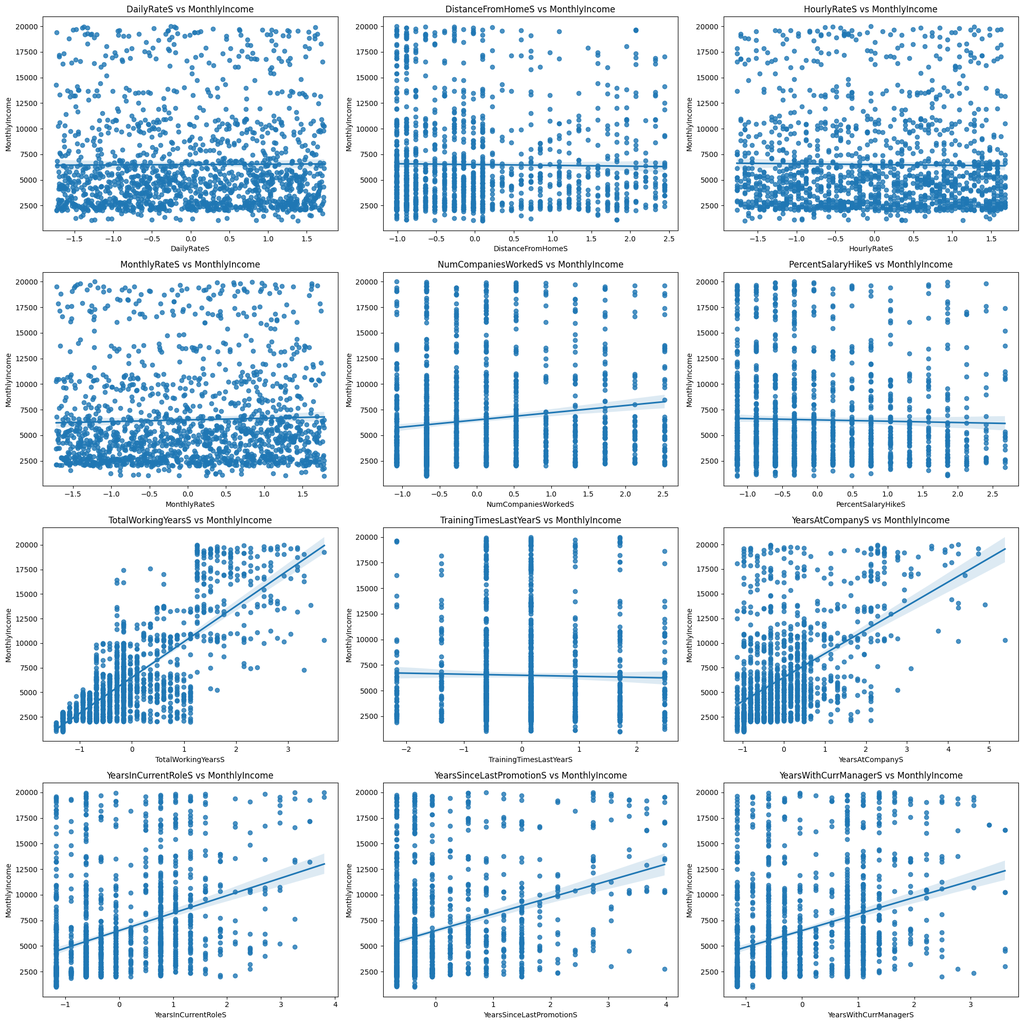

```python
# S2)  Check the linearity between dependent and all independent variables

import matplotlib.pyplot as plt
import seaborn as sns

# List of scaled continuous variables
scaled_cols = ['DailyRateS', 'DistanceFromHomeS', 'HourlyRateS', 'MonthlyRateS',
               'NumCompaniesWorkedS', 'PercentSalaryHikeS', 'TotalWorkingYearsS',
               'TrainingTimesLastYearS', 'YearsAtCompanyS', 'YearsInCurrentRoleS',
               'YearsSinceLastPromotionS', 'YearsWithCurrManagerS']

# Plot each independent variable against MonthlyIncome
plt.figure(figsize=(20, 20))
for i, col in enumerate(scaled_cols):
    plt.subplot(4, 3, i + 1)
    sns.regplot(x=df3[col], y=df3["MonthlyIncome"])
    plt.title(f'{col} vs MonthlyIncome')

plt.tight_layout()
plt.show()
```

After visualizing the relationship between the scaled continuous features and the target variable MonthlyIncome, we observe the following:

✅ Strong Positive Correlation The following features show a strong linear relationship with MonthlyIncome. As their values increase, MonthlyIncome tends to increase: TotalWorkingYearsS YearsAtCompanyS YearsInCurrentRoleS YearsSinceLastPromotionS YearsWithCurrManagerS These features are likely to be important predictors in our regression model.

⚠️ Weak or No Clear Relationship The following features do not show a strong trend with MonthlyIncome. The points appear scattered with no consistent pattern: DailyRateS DistanceFromHomeS HourlyRateS MonthlyRateS NumCompaniesWorkedS PercentSalaryHikeS TrainingTimesLastYearS These may contribute little predictive power and might be considered for removal or further analysis in later steps.

```python
#Step 3: Multicollinearity Check using VIF
from statsmodels.stats.outliers_influence import variance_inflation_factor
from statsmodels.tools.tools import add_constant

X = df3[['DailyRateS', 'DistanceFromHomeS', 'HourlyRateS', 'MonthlyRateS',
         'NumCompaniesWorkedS', 'PercentSalaryHikeS', 'TotalWorkingYearsS',
         'TrainingTimesLastYearS', 'YearsAtCompanyS', 'YearsInCurrentRoleS',
         'YearsSinceLastPromotionS', 'YearsWithCurrManagerS']]

# Add a constant for intercept
X_const = add_constant(X)

# Calculate VIF for each feature
vif_data = pd.DataFrame()
vif_data["Feature"] = X.columns
vif_data["VIF"] = [variance_inflation_factor(X_const.values, i+1) for i in range(len(X.columns))]

print(vif_data)
```

```
                     Feature       VIF
0                 DailyRateS  1.009993
1          DistanceFromHomeS  1.006304
2                HourlyRateS  1.003284
3               MonthlyRateS  1.007295
4        NumCompaniesWorkedS  1.219683
5         PercentSalaryHikeS  1.005541
6         TotalWorkingYearsS  1.987876
7     TrainingTimesLastYearS  1.006879
8            YearsAtCompanyS  4.520127
9        YearsInCurrentRoleS  2.683724
10  YearsSinceLastPromotionS  1.665823
11     YearsWithCurrManagerS  2.728108
```

Since all the VIF values are below 5 , there is no serious Multicollinearity issue in the dataset Hence , we keep all the variables for the regression model

```python
# Step 4 ) Train - Test - Split the dataset
from sklearn.model_selection import train_test_split

# Define features (X) and target (y)
X = df3[['DailyRateS', 'DistanceFromHomeS', 'HourlyRateS', 'MonthlyRateS',
         'NumCompaniesWorkedS', 'PercentSalaryHikeS', 'TotalWorkingYearsS',
         'TrainingTimesLastYearS', 'YearsAtCompanyS', 'YearsInCurrentRoleS',
         'YearsSinceLastPromotionS', 'YearsWithCurrManagerS']]
y = df3['MonthlyIncome']    # Target variable

# Train-test split (80% train, 20% test)
X_train, X_test, y_train, y_test = train_test_split(X, y, test_size=0.2, random_state=42)

# Confirm the shape
print("Training Features Shape:", X_train.shape)
print("Testing Features Shape:", X_test.shape)
```

```
Training Features Shape: (1176, 12)
Testing Features Shape: (294, 12)
```

```python
import statsmodels.api as sm

# Add a constant to the training data
X_train_sm = sm.add_constant(X_train)

# Build the OLS model
ols_model = sm.OLS(y_train, X_train_sm).fit()

# Print the model summary
print(ols_model.summary())
```

```
                            OLS Regression Results
==============================================================================
Dep. Variable:          MonthlyIncome   R-squared:                       0.603
Model:                            OLS   Adj. R-squared:                  0.599
Method:                 Least Squares   F-statistic:                     147.2
Date:                Wed, 09 Apr 2025   Prob (F-statistic):          2.21e-223
Time:                        07:44:04   Log-Likelihood:                -11071.
No. Observations:                1176   AIC:                         2.217e+04
Df Residuals:                    1163   BIC:                         2.223e+04
Df Model:                          12
Covariance Type:            nonrobust
============================================================================================
                               coef    std err          t      P>|t|      [0.025      0.975]
--------------------------------------------------------------------------------------------
const                     6456.9293     87.116     74.119      0.000    6286.007    6627.852
DailyRateS                  60.6183     86.815      0.698      0.485    -109.714     230.950
DistanceFromHomeS         -108.6878     86.911     -1.251      0.211    -279.208      61.833
HourlyRateS                -86.9492     86.543     -1.005      0.315    -256.747      82.849
MonthlyRateS               132.9191     87.495      1.519      0.129     -38.747     304.585
NumCompaniesWorkedS        -80.3726     96.317     -0.834      0.404    -269.346     108.601
PercentSalaryHikeS         -67.6741     87.134     -0.777      0.438    -238.632     103.284
TotalWorkingYearsS        3503.7261    123.605     28.346      0.000    3261.212    3746.240
TrainingTimesLastYearS      43.3633     86.719      0.500      0.617    -126.781     213.507
YearsAtCompanyS            393.4033    186.643      2.108      0.035      27.209     759.598
YearsInCurrentRoleS         27.3616    144.130      0.190      0.849    -255.423     310.146
YearsSinceLastPromotionS   136.6404    113.882      1.200      0.230     -86.796     360.077
YearsWithCurrManagerS     -394.5151    142.012     -2.778      0.006    -673.144    -115.886
==============================================================================
Omnibus:                       46.881   Durbin-Watson:                   2.049
Prob(Omnibus):                  0.000   Jarque-Bera (JB):               89.345
Skew:                           0.276   Prob(JB):                     3.97e-20
Kurtosis:                       4.232   Cond. No.                         4.55
==============================================================================

Notes:
[1] Standard Errors assume that the covariance matrix of the errors is correctly specified.
```

As the standardized value of Total Working Years increases by 1 unit, the Monthly Income increases by ₹3503.73, keeping all other factors constant. 🔑 Strongest positive influence on income.

An increase of 1 standard unit in Years at Company leads to an average increase of ₹393.40 in Monthly Income. ⬆️ Suggests loyalty to the company is rewarded with higher pay.

Surprisingly, as Years with Current Manager increases by 1 unit, Monthly Income tends to decrease by ₹394.51. ⚠️ Could indicate stagnation or missed opportunities under long-term management.

```python
from sklearn.linear_model import LinearRegression

# Define X and y
X_train_selected = X_train[['TotalWorkingYearsS', 'YearsAtCompanyS', 'YearsWithCurrManagerS']]
X_test_selected = X_test[['TotalWorkingYearsS', 'YearsAtCompanyS', 'YearsWithCurrManagerS']]
y_train = y_train
y_test = y_test

# Build the model
lr = LinearRegression()
lr.fit(X_train_selected, y_train)

# Predict
y_pred_train = lr.predict(X_train_selected)
y_pred_test = lr.predict(X_test_selected)
```

```python
from sklearn.metrics import mean_squared_error

# Calculate MSE
mse_train = mean_squared_error(y_train, y_pred_train)
mse_test = mean_squared_error(y_test, y_pred_test)

print("Train MSE:", mse_train)
print("Test MSE:", mse_test)
```

```
Train MSE: 8858217.780941557
Test MSE: 8714810.759449225
```

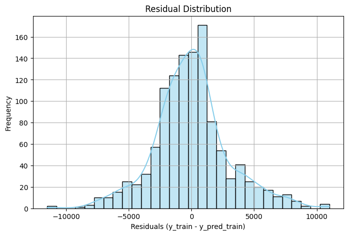

```python
import seaborn as sns
import matplotlib.pyplot as plt

# Calculate residuals
residuals = y_train - y_pred_train

# Plot residuals distribution
plt.figure(figsize=(8, 5))
sns.histplot(residuals, kde=True, bins=30, color='skyblue')
plt.title("Residual Distribution")
plt.xlabel("Residuals (y_train - y_pred_train)")
plt.ylabel("Frequency")
plt.grid(True)
plt.show()
```

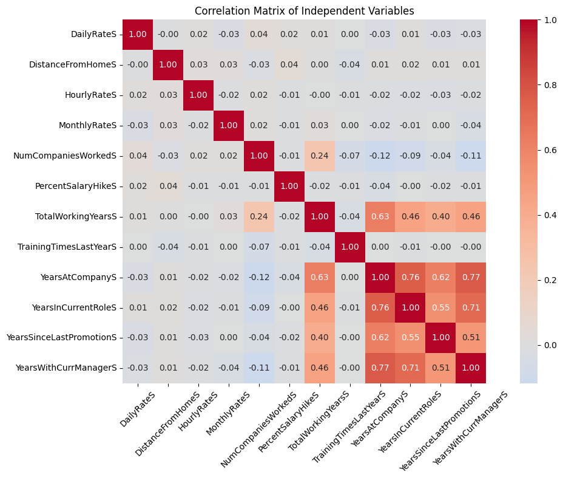

```python
import seaborn as sns
import matplotlib.pyplot as plt

# Select only the scaled independent features
X_scaled = df3[['DailyRateS', 'DistanceFromHomeS', 'HourlyRateS', 'MonthlyRateS',
                'NumCompaniesWorkedS', 'PercentSalaryHikeS', 'TotalWorkingYearsS',
                'TrainingTimesLastYearS', 'YearsAtCompanyS', 'YearsInCurrentRoleS',
                'YearsSinceLastPromotionS', 'YearsWithCurrManagerS']]

# Compute correlation matrix
corr_matrix = X_scaled.corr()

# Plot heatmap
plt.figure(figsize=(12, 8))
sns.heatmap(corr_matrix, annot=True, fmt=".2f", cmap='coolwarm', center=0, square=True)
plt.title("Correlation Matrix of Independent Variables")
plt.xticks(rotation=45)
plt.yticks(rotation=0)
plt.tight_layout()
plt.show()
```

While all features are within acceptable VIF limits (VIF < 5), the correlation matrix confirms that some variables are closely related.

No immediate action needed, since the multicollinearity is not extreme.

No strong multicollinearity. Your model is safe to use for linear regression interpretation.

Ridge and Lasso

```python
# Create df4 by copying df3
df4 = df3.copy()

# One-hot encode selected categorical columns
df4 = pd.get_dummies(df4, columns=[
    'BusinessTravel',
    'Department',
    'EducationField',
    'Gender',
    'JobRole',
    'MaritalStatus',
    'OverTime'
], drop_first=True)

# Show result
print(df4.head())
print("Shape of df4:", df4.shape)
```

```
       Attrition  DailyRate  DistanceFromHome  Education  EmployeeCount  \
0  41          1       1102                 1          2              1
1  49          0        279                 8          1              1
2  37          1       1373                 2          2              1
3  33          0       1392                 3          4              1
4  27          0        591                 2          1              1

   EmployeeNumber  EnvironmentSatisfaction  HourlyRate  JobInvolvement  ...  \
0               1                        2          94               3  ...
1               2                        3          61               2  ...
2               4                        4          92               2  ...
3               5                        4          56               3  ...
4               7                        1          40               3  ...

   JobRole_2  JobRole_3  JobRole_4  JobRole_5  JobRole_6 JobRole_7  JobRole_8  \
0      False      False      False      False      False      True      False
1      False      False      False      False       True     False      False
2       True      False      False      False      False     False      False
3      False      False      False      False       True     False      False
4       True      False      False      False      False     False      False

   MaritalStatus_1  MaritalStatus_2  OverTime_1
0            False             True        True
1             True            False       False
2            False             True        True
3             True            False        True
4             True            False       False

[5 rows x 62 columns]
Shape of df4: (1470, 62)
```

```python
df4.columns
```

```
Index(['  ', 'Attrition', 'DailyRate', 'DistanceFromHome', 'Education',
       'EmployeeCount', 'EmployeeNumber', 'EnvironmentSatisfaction',
       'HourlyRate', 'JobInvolvement', 'JobLevel', 'JobSatisfaction',
       'MonthlyIncome', 'MonthlyRate', 'NumCompaniesWorked', 'Over18',
       'PercentSalaryHike', 'PerformanceRating', 'RelationshipSatisfaction',
       'StandardHours', 'StockOptionLevel', 'TotalWorkingYears',
       'TrainingTimesLastYear', 'WorkLifeBalance', 'YearsAtCompany',
       'YearsInCurrentRole', 'YearsSinceLastPromotion', 'YearsWithCurrManager',
       'Group', 'DailyRateS', 'DistanceFromHomeS', 'HourlyRateS',
       'MonthlyRateS', 'NumCompaniesWorkedS', 'PercentSalaryHikeS',
       'TotalWorkingYearsS', 'TrainingTimesLastYearS', 'YearsAtCompanyS',
       'YearsInCurrentRoleS', 'YearsSinceLastPromotionS',
       'YearsWithCurrManagerS', 'BusinessTravel_1', 'BusinessTravel_2',
       'Department_1', 'Department_2', 'EducationField_1', 'EducationField_2',
       'EducationField_3', 'EducationField_4', 'EducationField_5', 'Gender_1',
       'JobRole_1', 'JobRole_2', 'JobRole_3', 'JobRole_4', 'JobRole_5',
       'JobRole_6', 'JobRole_7', 'JobRole_8', 'MaritalStatus_1',
       'MaritalStatus_2', 'OverTime_1'],
      dtype='object')
```

```python
df4_clean = df4.drop(columns=['Over18', 'EmployeeNumber', 'EmployeeCount', 'StandardHours', 'Attrition'])
```

```python
from sklearn.model_selection import train_test_split

X = df4.drop(columns=['MonthlyIncome'])
y = df4['MonthlyIncome']

X_train, X_test, y_train, y_test = train_test_split(X, y, test_size=0.2, random_state=42)
```

```python
cols_to_drop = ['Attrition', 'EmployeeNumber', 'Over18', 'EmployeeCount', 'StandardHours',"Group"]
df4 = df4.drop(columns=cols_to_drop)
```

```python
from sklearn.linear_model import Ridge
from sklearn.metrics import mean_squared_error

ridge = Ridge(alpha=0.7599555414764666)
ridge.fit(X_train, y_train)

y_pred_ridge = ridge.predict(X_test)
mse_ridge = mean_squared_error(y_test, y_pred_ridge)

print(pd.Series(ridge.coef_, index=X.columns))

print("Ridge MSE:", mse_ridge)
```

[output not shown]

most important features based on absolute coefficient values:

📈 Top Positive Influences on Monthly Income These increase the predicted monthly income:

JobRole is the most dominant factor. Some roles (like JobRole_3 and JobRole_5) increase income a lot, while others (like JobRole_2 and JobRole_6) reduce it. Higher JobLevel increases salary significantly. PerformanceRating surprisingly has a negative coefficient – possibly due to correlation with other variables. Categorical fields like BusinessTravel and Department are important predictors.

```python
alphas = 10 ** np.linspace(10,-2,100)* 0.5
ridge = Ridge()
coefs = []

for a in alphas:
    ridge.set_params(alpha = a)
    ridge.fit(X,y)
    coefs.append(ridge.coef_)
np.shape(coefs)
```

```
(100, 55)
```

```python
ridgecv = RidgeCV(alphas = alphas)
ridgecv.fit(X_train , y_train)
ridgecv.alpha_
```

```
0.7599555414764666
```

```python
from sklearn.linear_model import Lasso

lasso = Lasso(alpha=5.361336110051605)
lasso.fit(X_train, y_train)

y_pred_lasso = lasso.predict(X_test)
mse_lasso = mean_squared_error(y_test, y_pred_lasso)
print(pd.Series(lasso.coef_ , index = X.columns))
print("Lasso MSE:", mse_lasso)
```

```
                              -3.415505
DailyRate                      0.073384
DistanceFromHome              -4.577515
Education                      0.000000
EnvironmentSatisfaction      -11.069344
HourlyRate                     0.975135
JobInvolvement               -61.538415
JobLevel                    2943.037907
JobSatisfaction              -20.700994
MonthlyRate                   -0.003208
NumCompaniesWorked            13.023840
PercentSalaryHike              5.607591
PerformanceRating            -61.881388
RelationshipSatisfaction      21.470495
StockOptionLevel              -7.436712
TotalWorkingYears             41.440214
TrainingTimesLastYear         -6.176305
WorkLifeBalance              -46.230914
YearsAtCompany                 3.752114
YearsInCurrentRole             0.000000
YearsSinceLastPromotion       27.133407
YearsWithCurrManager         -27.565017
DailyRateS                     0.000000
DistanceFromHomeS             -0.000000
HourlyRateS                    0.000000
MonthlyRateS                  -0.000000
NumCompaniesWorkedS            0.000000
PercentSalaryHikeS             0.000000
TotalWorkingYearsS             0.000000
TrainingTimesLastYearS        -0.000000
YearsAtCompanyS                0.000000
YearsInCurrentRoleS            0.000000
YearsSinceLastPromotionS       0.000000
YearsWithCurrManagerS         -0.000000
BusinessTravel_1               1.465941
BusinessTravel_2              34.296123
Department_1                   0.000000
Department_2                  -0.000000
EducationField_1              -0.000000
EducationField_2               0.000000
EducationField_3              31.884855
EducationField_4             -29.842075
EducationField_5               0.000000
Gender_1                       9.859199
JobRole_1                     -0.000000
JobRole_2                   -303.010205
JobRole_3                   3875.229293
JobRole_4                      0.000000
JobRole_5                   3681.896444
JobRole_6                   -194.969699
JobRole_7                     25.295105
JobRole_8                   -309.825887
MaritalStatus_1                0.400296
MaritalStatus_2               -0.000000
OverTime_1                    34.013969
dtype: float64
Lasso MSE: 1375910.3768438858
```

📈 Strong Positive Influence: JobRole_3: +3875.23 JobRole_5: +3681.90 JobLevel: +2943.04 TotalWorkingYears: +41.44 YearsSinceLastPromotion: +27.13 EducationField_3: +31.88 BusinessTravel_2: +34.30 OverTime_1: +34.01 📉 Strong Negative Influence: JobRole_2: –303.01 JobRole_8: –309.83 JobRole_6: –194.97 PerformanceRating: –61.88 JobInvolvement: –61.54 EnvironmentSatisfaction: –11.07 Lasso removed a lot of features (coefficients became 0), which helps in creating a simpler model. Still, your top predictors remain similar to Ridge: JobRole, JobLevel, TotalWorkingYears, PerformanceRating, and YearsSinceLastPromotion. Lasso can be used if you want to reduce model complexity and identify only the most relevant variables.

```python
lassocv = LassoCV(alphas = alphas)
lassocv.fit(X_train , y_train)
lassocv.alpha_
```

```
5.361336110051605
```

FINAL REGRESSION MODEL

```python
final_features = [
    'DailyRate',
    'DistanceFromHome',
    'EnvironmentSatisfaction',
    'HourlyRate',
    'JobInvolvement',
    'JobLevel',
    'JobSatisfaction',
    'MonthlyRate',
    'NumCompaniesWorked',
    'PercentSalaryHike',
    'PerformanceRating',
    'RelationshipSatisfaction',
    'StockOptionLevel',
    'TotalWorkingYears',
    'TrainingTimesLastYear',
    'WorkLifeBalance',
    'YearsAtCompany',
    'YearsSinceLastPromotion',
    'YearsWithCurrManager',
    'BusinessTravel_1',
    'BusinessTravel_2',
    'EducationField_3',
    'EducationField_4',
    'Gender_1',
    'JobRole_2',
    'JobRole_3',
    'JobRole_5',
    'JobRole_6',
    'JobRole_7',
    'JobRole_8',
    'MaritalStatus_1',
    'OverTime_1'
]
```

```python
from sklearn.linear_model import LinearRegression
from sklearn.metrics import mean_squared_error, r2_score
import statsmodels.api as sm

# Define X and y
X_final = df4[final_features]
y_final = y

# Train-test split
from sklearn.model_selection import train_test_split
X_train, X_test, y_train, y_test = train_test_split(X_final, y_final, test_size=0.2, random_state=42)

# Train the model
model_final = LinearRegression()
model_final.fit(X_train, y_train)

# Predict
y_pred = model_final.predict(X_test)

# Evaluation
mse = mean_squared_error(y_test, y_pred)
r2 = r2_score(y_test, y_pred)
print(f"Final Model MSE: {mse}")

# Optional: OLS summary
X_ols = sm.add_constant(X_final)
ols_model = sm.OLS(y_final, X_ols).fit()
print(ols_model.summary())
```

```
Final Model MSE: 1360391.2208037823
                            OLS Regression Results
==============================================================================
Dep. Variable:          MonthlyIncome   R-squared:                       0.945
Model:                            OLS   Adj. R-squared:                  0.943
Method:                 Least Squares   F-statistic:                     765.7
Date:                Wed, 09 Apr 2025   Prob (F-statistic):               0.00
Time:                        08:28:08   Log-Likelihood:                -12391.
No. Observations:                1470   AIC:                         2.485e+04
Df Residuals:                    1437   BIC:                         2.502e+04
Df Model:                          32
Covariance Type:            nonrobust
============================================================================================
                               coef    std err          t      P>|t|      [0.025      0.975]
--------------------------------------------------------------------------------------------
const                      336.2786    425.380      0.791      0.429    -498.154    1170.711
DailyRate                    0.0906      0.073      1.241      0.215      -0.053       0.234
DistanceFromHome            -4.5586      3.637     -1.253      0.210     -11.694       2.577
EnvironmentSatisfaction      0.9797     27.049      0.036      0.971     -52.080      54.039
HourlyRate                   1.3419      1.453      0.923      0.356      -1.509       4.193
JobInvolvement             -93.8729     41.536     -2.260      0.024    -175.351     -12.395
JobLevel                  2783.2411     65.001     42.818      0.000    2655.734    2910.748
JobSatisfaction            -10.6789     26.739     -0.399      0.690     -63.131      41.773
MonthlyRate                 -0.0047      0.004     -1.125      0.261      -0.013       0.003
NumCompaniesWorked           7.9468     13.091      0.607      0.544     -17.733      33.627
PercentSalaryHike           18.0723     12.734      1.419      0.156      -6.907      43.052
PerformanceRating         -173.1867    128.972     -1.343      0.180    -426.180      79.807
RelationshipSatisfaction    15.0059     27.296      0.550      0.583     -38.538      68.550
StockOptionLevel           -35.0185     35.516     -0.986      0.324    -104.687      34.650
TotalWorkingYears           42.1704      7.186      5.869      0.000      28.075      56.266
TrainingTimesLastYear      -18.3807     23.024     -0.798      0.425     -63.544      26.783
WorkLifeBalance            -23.5748     41.700     -0.565      0.572    -105.375      58.225
YearsAtCompany               6.0574      9.544      0.635      0.526     -12.663      24.778
YearsSinceLastPromotion     25.3644     11.658      2.176      0.030       2.495      48.234
YearsWithCurrManager       -30.2118     13.173     -2.293      0.022     -56.053      -4.371
BusinessTravel_1           153.5302    114.735      1.338      0.181     -71.536     378.596
BusinessTravel_2           175.5821     98.849      1.776      0.076     -18.322     369.486
EducationField_3           -20.1385     65.200     -0.309      0.757    -148.035     107.758
EducationField_4          -108.2362    130.647     -0.828      0.408    -364.516     148.043
Gender_1                    86.3744     60.273      1.433      0.152     -31.859     204.607
JobRole_2                 -480.7315    109.192     -4.403      0.000    -694.923    -266.540
JobRole_3                 4170.3614    165.167     25.249      0.000    3846.367    4494.356
JobRole_5                 4113.4911    165.717     24.822      0.000    3788.417    4438.565
JobRole_6                 -393.1179    107.664     -3.651      0.000    -604.314    -181.922
JobRole_7                   27.8682     89.201      0.312      0.755    -147.109     202.846
JobRole_8                 -580.4579    153.464     -3.782      0.000    -881.495    -279.421
MaritalStatus_1             45.8557     60.791      0.754      0.451     -73.393     165.104
OverTime_1                  67.4775     65.867      1.024      0.306     -61.728     196.683
==============================================================================
Omnibus:                       49.907   Durbin-Watson:                   2.038
Prob(Omnibus):                  0.000   Jarque-Bera (JB):              100.119
Skew:                           0.216   Prob(JB):                     1.82e-22
Kurtosis:                       4.203   Cond. No.                     2.40e+05
==============================================================================

Notes:
[1] Standard Errors assume that the covariance matrix of the errors is correctly specified.
[2] The condition number is large, 2.4e+05. This might indicate that there are
strong multicollinearity or other numerical problems.
```

variables with p-values less than 0.05, meaning they are statistically significant predictors of MonthlyIncome in your final OLS model: JobInvolvement (p = 0.024) JobLevel (p = 0.000) TotalWorkingYears (p = 0.000) YearsSinceLastPromotion (p = 0.030) YearsWithCurrManager (p = 0.022) JobRole_2 (p = 0.000) JobRole_3 (p = 0.000) JobRole_5 (p = 0.000) JobRole_6 (p = 0.000) JobRole_8 (p = 0.000) These are the most influential variables in predicting Monthly Income based on your model.

```python
bool_columns = [
    'BusinessTravel_1', 'BusinessTravel_2', 'EducationField_3', 'EducationField_4',
    'Gender_1', 'JobRole_2', 'JobRole_3', 'JobRole_5', 'JobRole_6',
    'JobRole_7', 'JobRole_8', 'MaritalStatus_1', 'OverTime_1'
]

df4[bool_columns] = df4[bool_columns].astype(int)
```

CONCLUSION

In this project, we explored the factors influencing employee Monthly Income using various statistical and machine learning techniques on the HR Employee Attrition dataset.

🔹 1. Initial Linear Regression Model The initial model included many predictors, but most had high p-values (p > 0.05), indicating insignificance. Variables like EnvironmentSatisfaction, JobSatisfaction, HourlyRate, and many categorical features did not meaningfully explain the variation in income. This led to an overfit and complex model with lower interpretability.

🔹 4. Lasso Regression Lasso performed both regularization and feature selection by shrinking some coefficients exactly to zero. It helped in identifying the most relevant predictors, matching the variables that showed significance in the refined OLS model. Key variables retained: JobLevel, TotalWorkingYears, JobRole, and YearsSinceLastPromotion.